### *CITI - Credit Rating Models*

# How to assess if Apple defaults?

Understanding Business Report

Prepared by: Alberto Delgado Lopez, Serena Bozheku and Jabir Kangarli

## Content

### 1. Business Problem

### 2. Data Analysis

```
2.1 Reading data
2.2 Exploratory Data analysis
```

### 3. Reproduction of the model

### 4. Building new models

```
4.1 Proposed models
4.2 Balancing data
```

### 5. Conclusion

### 6. Annex

## 1. Business Problem

Following the financial crisis of 2008, banks began to pay more attention to credit risk, which is believed to be among the root causes of the crisis.

Credit risk occurs when a borrower fails to make required payments on a debt. For financial institutions and other lenders, the risk is an inherent part of the lending paradigm. It is difficult to determine the level of risk associated with each loan. The probability of default, the amount of exposure at the time of default, how much the loan is expected to be worth at the time of default, and the overall loss if there is a default are all factors that go into the complex credit risk calculation.

Credit risk itself has the following main types:

- Credit default risk
- Concentration risk
- Probability of Default (POD)
- Loss Given Default (LGD)
- Exposure at Default (EAD)

Credit institutions now have a plethora of models at their disposal for estimating credit risk and, thus, the likelihood of default. These models look for behavioral patterns from historical data to guess how a consumer will behave in the future.

Some of the models used for predicting binary outcomes such as default/non-default include logistic regression, decision trees, neural networks, and Naive Bayes classifier. However, despite their diversity and undeniable benefits to banking system stability, these models are not always adequate to deal with the complex circumstances that characterize many economies.

CITI, as one of the leading corporate banks in the world, puts a huge amount of effort and teamwork to develop models and have solid outputs of the developed models which assess their clients’ credit risk.

The aim of our case is to build a model which is assessing one-year probability of default of a company. We worked on two given datasets to develop a model which would give better results than the original one. The original dataset used for developing the original model contained obligors from North America region and their financials variables.

The project will follow the flow below:

[figure not shown]

A heatmap was used for visualizing correlations.

In the end, 22 variables out of the initial 51 were selected.

In order to build the model which will give the best results the following steps should be used:

[figure not shown]

## 2. Data Analysis

### 2.1 Reading data

```python
#importing needed packages

import pandas as pd
import seaborn as sns
import matplotlib.pyplot as plt
import os
import numpy as np
import tools
import statsmodels.api as sm

from xgboost import XGBClassifier
from lightgbm import LGBMClassifier
from varclushi import VarClusHi

from sklearn.linear_model.logistic import LogisticRegression
from sklearn.utils import resample
from sklearn.pipeline import Pipeline
from sklearn.model_selection import GridSearchCV, RandomizedSearchCV,train_test_split, cross_val_score
from sklearn.ensemble import RandomForestClassifier,RandomForestRegressor
from sklearn.feature_selection import SelectFromModel
from sklearn.preprocessing import StandardScaler
from sklearn.metrics import mean_squared_error, r2_score, roc_curve, auc, roc_auc_score, classification_report, confusion_matrix, precision_recall_curve, average_precision_score
```

```python
#Reading the data

dev_dataset=pd.read_csv('development_dataset.csv')
test_dataset=pd.read_csv('testing_dataset.csv')
full_dataset=pd.concat([dev_dataset, test_dataset], axis=0)
full_dataset.drop('const', inplace=True, axis=1)
full_dataset.drop('champion_model_with_logit_logit_pred', inplace=True, axis=1)
full_dataset.drop('Unnamed: 0', inplace=True, axis=1)

full_dataset.head()
```

|  | EBIT | Growth in Leverage | ROA | CashRatio | Debt to Assets | IntExp to Total Assets | Ebitda to Total Debt | Default Flag | Tangible Net Worth | Free Cash Flow | ... | Growth in Stock.Eq. | Retained Earnings | Tot.Liab. To Tangible Net Worth | Tangible Net Worth to Tot.Liab | Tot.Liab. To Net Worth | Net Worth to Total Liabilities | year | GFCID | Age | time of entry |
| --- | --- | --- | --- | --- | --- | --- | --- | --- | --- | --- | --- | --- | --- | --- | --- | --- | --- | --- | --- | --- | --- |
| 0 | 5.080351 | -2.391316 | -2.531003 | 0.346380 | -0.281023 | -1.764996 | -1.170840 | 0 | 356.182399 | -100.930486 | ... | -0.018349 | 270.306280 | 0.332091 | 0.331269 | 0.332091 | 0.331269 | 1992.0 | 0 | 3.0 | 2.0 |
| 1 | 5.929835 | -2.861229 | -1.719335 | 0.041694 | -0.533332 | -1.858300 | -0.353243 | 0 | 372.695269 | -203.515736 | ... | 0.127706 | 286.819150 | 0.355096 | 0.354369 | 0.355096 | 0.354369 | 1993.0 | 0 | 4.0 | 3.0 |
| 2 | 4.881674 | -3.107091 | -2.263367 | 0.207251 | -0.539617 | -2.082354 | -1.049053 | 0 | 443.065619 | -323.508807 | ... | 0.287499 | 357.159220 | 0.389056 | 0.394133 | 0.389056 | 0.389056 | 1994.0 | 0 | 5.0 | 4.0 |
| 3 | 5.552164 | -2.965286 | -2.098814 | -1.491426 | -0.435552 | -2.043641 | -0.918444 | 0 | 530.766407 | -270.204223 | ... | 0.297729 | 444.860008 | 0.421158 | 0.425830 | 0.421158 | 0.421158 | 1995.0 | 0 | 6.0 | 5.0 |
| 4 | 5.676371 | -3.170750 | -1.934131 | -1.921948 | -0.471665 | -2.030996 | -0.808868 | 0 | 641.906410 | -258.877139 | ... | 0.310570 | 556.000010 | 0.467085 | 0.471462 | 0.467085 | 0.467085 | 1996.0 | 0 | 7.0 | 6.0 |

5 rows × 21 columns

```python
full_dataset.info()
```

```
<class 'pandas.core.frame.DataFrame'>
Int64Index: 16388 entries, 0 to 455
Data columns (total 21 columns):
 #   Column                           Non-Null Count  Dtype
---  ------                           --------------  -----
 0   EBIT                             16388 non-null  float64
 1   Growth in Leverage               16388 non-null  float64
 2   ROA                              16388 non-null  float64
 3   CashRatio                        16388 non-null  float64
 4   Debt to Assets                   16388 non-null  float64
 5   IntExp to Total Assets           16388 non-null  float64
 6   Ebitda to Total Debt             16388 non-null  float64
 7   Default Flag                     16388 non-null  int64
 8   Tangible Net Worth               16388 non-null  float64
 9   Free Cash Flow                   16388 non-null  float64
 10  REALGROWTHINSTOCKEQ              16388 non-null  float64
 11  Growth in Stock.Eq.              16388 non-null  float64
 12  Retained Earnings                16388 non-null  float64
 13  Tot.Liab. To Tangible Net Worth  16388 non-null  float64
 14  Tangible Net Worth to Tot.Liab   16388 non-null  float64
 15  Tot.Liab. To Net Worth           16388 non-null  float64
 16  Net Worth to Total Liabilities   16388 non-null  float64
 17  year                             16388 non-null  float64
 18  GFCID                            16388 non-null  int64
 19  Age                              16388 non-null  float64
 20  time of entry                    16388 non-null  float64
dtypes: float64(19), int64(2)
memory usage: 2.8 MB
```

- *EBIT* - earnings before interest and taxes (revenue -expenses (excluding tax and interest)). It’s useful because it helps identify a company’s ability to generate enough earnings to be profitable, pay its own debt and fund ongoing operations
- *Growth in Leverage* - refers to the use of debt (borrowed funds) to amplify returns from an investment or project. A highly leveraged company has more debt than equity
- *ROA (Return On Assets)* - measure of how much profit a business generates from its capital. ROA = net income/ total assets. Higher ROA, more efficient the company is at generating profits
- *The cash ratio* – A measurement of a company’s liquidity, specifically the ratio of a company’s total cash and cash equivalents to its current liabilities. It calculates the company’s ability to pay its short-term debt with cash or near-cash resources
- *Total debt to total assets* – A leverage ratio that defines the total amount of debt relative to assets owned by a company. It can reflect how financially stable a company is. The higher the ratio, the higher the degree of leverage and consequently, the higher the risk of investing in that company
- *EBITDA to total Debt* - DEBT/EBITDA (EBITDA- earnings before taxes, depreciation and amortization). It’s a ratio that measures the amount of income generated and available to pay down debt before covering interest, taxes, depreciation and amortization. A high ratio can indicate a company has a too-heavy debt load
- *Tangible net worth* - determined by deducting intangible assets from the total net worth of a company. (Intangible assets include intellectual property rights such as patents, copyrights and company goodwill. These assets cannot be easily converted to cash and are less valuable to lenders.) Higher result is better
- *Free cash flow (FCF)* - represents the cash a company generates after accounting for cash outflows to support operations and maintain its capital assets
- *Retained earnings* - the amount of net income left over for the business after it has paid out dividends to its shareholders. Retained earnings could be used for funding an expansion or paying dividends to shareholders at a later date and etc
- *Tot.Liab. To Tangible Net Worth* - Companies with low amounts of debt compared to their tangible net worth are considered financially healthier than firms with higher levels of debt.
- *Real Growth in Stock Equity* - Stockholder's equity is the total value of assets owned by an investor after deducting and settling liabilities.

### 2.2 Exploratory Data analysis

#### Target variable

```python
np.unique(full_dataset[full_dataset['Default Flag']==1]['year'])
```

```
array([1992., 1993., 1994., 1995., 1996., 1998., 1999., 2000., 2001.,
       2002., 2003., 2004., 2007., 2008., 2009., 2011., 2012., 2013.,
       2014., 2015., 2019.])
```

```python
full_dataset[full_dataset['Default Flag']==1].groupby('year')['Default Flag'].count()
```

```
year
1992.0     1
1993.0     1
1994.0     3
1995.0     3
1996.0     1
1998.0     4
1999.0     9
2000.0    10
2001.0     4
2002.0     4
2003.0     1
2004.0     2
2007.0     2
2008.0     5
2009.0     3
2011.0     3
2012.0     1
2013.0     1
2014.0     1
2015.0     2
2019.0     3
Name: Default Flag, dtype: int64
```

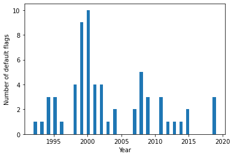

```python
fig = plt.hist(full_dataset.year[full_dataset['Default Flag'] == 1], bins = 55)

plt.xlabel('Year')
plt.ylabel('Number of default flags')
plt.show()
```

```python
DF = [len(full_dataset.loc[full_dataset['Default Flag'] == 1]), len(full_dataset.loc[full_dataset['Default Flag'] == 0])]
pd.Series(DF, index = ['Default', 'Non-Default'], name = 'Default Flag')
```

```
Default           64
Non-Default    16324
Name: Default Flag, dtype: int64
```

```python
print('% of Default Flag = {:.3f}%'.format(len(full_dataset[full_dataset['Default Flag'] == 1])*100 / len(full_dataset)))
```

```
% of Default Flag = 0.391%
```

As we can see in the analysis from the target variable 'Default Flag', the dataset is very imbalanced. The number of 1-Defaults is only a 0.4% of the whole data.

Also, the amount of Defaults is different from year to year, with the majority observed in the early 2000's, existing also some years with no defaults at all.

#### Independent variables

We decided to add to the model the following four variables: Tangible Net Worth, REALGROWTHINSTOCKEQ, Free Cash Flow, Tot.Liab. To Tangible Net Worth. The reason for this is that we believe that this variables would be good indicators of the financial health of a company as they represent the level of creditors' protection in case of the firm's insolvency.

[figure not shown]

As we can see in the plot above, none of the variables we have chosen are highly correlated with the rest. So, this is a safe scenario to keep working on this.

### 3. Reproduction of the model

Initially, we were struggling to reproduce the original results. We realized that the original model was using a function built by CITI. After contacting them, we got the code of the function which can be seen below.

```python
def building_logit_models(dev_dataset, logit_models, testing_dataset=None,
                           table_of_models=None, addtional_analyses_columns=None):
    """
    Created on Mon Sep 22 12:24:57 2021

    @author: db66143

    """

    from sklearn.metrics import roc_curve
    from sklearn.metrics import roc_auc_score
    import statsmodels.api as sm
    from statsmodels.stats.outliers_influence import variance_inflation_factor
    import matplotlib.pyplot as plt
    import pandas as pd
    import numpy as np
    import os
    import sys

    # initilization of tabels and paths
    if table_of_models is None:
        table_of_models = pd.DataFrame(columns=['model', 'model_type', 'variables', 'number_of_var',
                                        'AR', 'AUC', 'params', 'p_vals', 'VIF', 'Wald_test_joined',
                                        '-2LOG L', 'AIC', 'BIC', 'HQIC'])
    if not os.path.isdir('models'):
        os.mkdir('models')

    ### fitting challengers
    for model_name, model_params in logit_models.items():

        ### Logit input preparation
        # adding constant if not in dataset

        if 'const' not in model_params['exog']:
            print('adding const')
            dev_dataset = sm.add_constant(dev_dataset, prepend=False, has_constant='skip' )
            model_params['exog'] += ['const']
            if testing_dataset is not None:
                testing_dataset = sm.add_constant(testing_dataset, prepend=False, has_constant='skip' )

        # splitting params to dataset related and not
        target = model_params['endog']
        model_variables = model_params['exog']
        logit_model_input = {}
        for key, val in model_params.items():
            try:
                logit_model_input[key] = dev_dataset[val]
            except KeyError:
                logit_model_input[key] = val

        ### Logit
        logit = sm.Logit(**logit_model_input)
        challenger_model = logit.fit()

        dev_dataset['temp_pred'] = challenger_model.predict()
        challenger_auc = roc_auc_score(dev_dataset[target], dev_dataset['temp_pred'])
        challenger_ar = 2*challenger_auc-1
        print(model_name, model_variables, round(challenger_ar,2))

        VIF = np.array([variance_inflation_factor(dev_dataset[model_variables].values, i)
                              for i in range(len(dev_dataset[model_variables].columns))])


        gather_params = {}
        gather_params['model'] = str(model_name)
        gather_params['variables'] = str(model_variables)
        gather_params['model_type'] = 'logit'
        gather_params['number_of_var'] = len(model_variables)
        gather_params['AR'] = challenger_ar
        gather_params['AUC'] = challenger_auc
        gather_params['params'] =str(dict(zip(model_variables , challenger_model.params.tolist())))
        gather_params['p_vals'] = str(dict(zip(model_variables , challenger_model.pvalues)))
        gather_params['VIF']  = str(dict(zip(model_variables , VIF)))

        # Wald test joined significance
        # http://web.sgh.waw.pl/~jmuck/Ekonometria/EkonometriaPrezentacja2.pdf (slide 20)
        # r_matrix calculation (This tests that each coefficient is jointly statistically significantly different from zero.)
        # https://www.statsmodels.org/stable/generated/statsmodels.duration.hazard_regression.PHRegResults.f_test.html#statsmodels.duration.hazard_regression.PHRegResults.f_test (r_matrix)
        # Wald test in cox ph:
        # https://www.statsmodels.org/stable/generated/statsmodels.duration.hazard_regression.PHRegResults.wald_test.html#statsmodels.duration.hazard_regression.PHRegResults.wald_test

        r_matrix = np.identity(len(challenger_model.params))[1:,:]
        gather_params['Wald_test_joined']  = challenger_model.wald_test(r_matrix).summary()

        # information criteria

        llf = challenger_model.llf #log_likelihood_of_model
        gather_params['-2LOG L']  = (-2)*llf
        gather_params['AIC']  = sm.tools.eval_measures.aic(llf, nobs=len(dev_dataset), df_modelwc=len(challenger_model.params))
        gather_params['BIC']  = sm.tools.eval_measures.bic(llf, nobs=len(dev_dataset), df_modelwc=len(challenger_model.params))
        gather_params['HQIC']  = sm.tools.eval_measures.hqic(llf, nobs=len(dev_dataset), df_modelwc=len(challenger_model.params))


        # addtional_AR_analyses
        if addtional_analyses_columns is not None:
            for column in addtional_analyses_columns:
                gather_subgroup_params = {}
                for subgroup in dev_dataset[column].unique():
                    # Value error while no defaults for given subgroup
                    try:
                       gather_subgroup_params[subgroup] = 2 * roc_auc_score(
                                    dev_dataset[dev_dataset[column]==subgroup][target],
                                    dev_dataset[dev_dataset[column]==subgroup]['temp_pred'])-1
                    except ValueError:
                        gather_subgroup_params[subgroup] = 'no defaults'

                gather_params['AR_per_'+column+'_devdataset'] = str(gather_subgroup_params)


        #ROC chart
        fpr, tpr, thresholds = roc_curve(dev_dataset[target], challenger_model.predict())
        plt.figure()
        plt.plot(fpr, tpr, label='Accuracy Ratio = %0.4f' % challenger_ar)
        plt.plot([0, 1], [0, 1],'r--')
        plt.xlim([0.0, 1.0])
        plt.ylim([0.0, 1.05])
        plt.title(rf'{model_name} - Receiver operating characteristic curve (ROC)'.format(model_name))
        plt.xlabel('Percent of Sample Ordered by Score')
        plt.ylabel('Percent of Target')
        plt.legend(loc='lower right')
        plt.savefig(rf'models/{model_name} Receiver operating characteristic curve (ROC).png'.format(model_name),
                    bbox_inches='tight')
        plt.close()


        # testing set
        if testing_dataset is not None:
            testing_dataset['temp_pred'] = challenger_model.predict(exog=testing_dataset[model_variables])
            try:
                gather_params['AUC_testing_dataset'] = roc_auc_score(testing_dataset[target],
                                                                            testing_dataset['temp_pred'])
                gather_params['AR_testing_dataset'] = 2 * gather_params['AUC_testing_dataset'] - 1
            except ValueError:
                gather_params['AUC_testing_dataset'] = 'no defaults'
                gather_params['AR_testing_dataset'] = 'no defaults'

            # addtional_AR_analyses
            if addtional_analyses_columns is not None:
                for column in addtional_analyses_columns:
                    gather_subgroup_params = {}
                    for subgroup in testing_dataset[column].unique():
                        # Value error while no defaults for given subgroup
                        try:
                           gather_subgroup_params[subgroup] = 2 * roc_auc_score(
                                        testing_dataset[testing_dataset[column]==subgroup][target],
                                        testing_dataset[testing_dataset[column]==subgroup]['temp_pred'])-1
                        except ValueError:
                            gather_subgroup_params[subgroup] = 'no defaults'

                    gather_params['AR_per_'+column+'_testing_dataset'] = str(gather_subgroup_params)
            testing_dataset.rename(columns={'temp_pred': model_name+'_logit_pred'}, inplace=True)

        table_of_models = table_of_models.append(gather_params, ignore_index=True)
        dev_dataset.rename(columns={'temp_pred': model_name+'_logit_pred'}, inplace=True)


        # saving params to .txt file
        with open('models/'+model_name+'_model_summary.txt', 'w') as f:
            f.write('Model summary:')
            f.write(challenger_model.summary().as_text())
            f.write('\n\nWald test:')
            f.write(challenger_model.wald_test_terms().table.to_string())
            f.write('\n\n\n')
            for key, val in gather_params.items():
                f.write('\n{}:'.format(key))
                f.write('{}'.format(val))
                f.write('\n')

    return dev_dataset, testing_dataset, table_of_models
```

Results from the original model after reproduction:

[figure not shown]

Also after different trials, we observed that the performance of the model was improved by choosing a different year than the year 2020 for testing the trained model, since this year had no defaults records. Let's proceed to rerun the model with the four added variables and different year:

```python
dev=full_dataset[full_dataset.year!=2015]
test_pred=full_dataset[full_dataset.year==2015]

test_pred['const']=1

addtional_analyses_columns = []

table_of_models=pd.DataFrame()
### logit
logit_models = {
    'champion_model_with_logit':
        {'endog': 'Default Flag',
         'exog':['EBIT','Growth in Leverage','ROA','CashRatio','Debt to Assets','IntExp to Total Assets',
             'Ebitda to Total Debt','Tangible Net Worth','REALGROWTHINSTOCKEQ','Free Cash Flow','Tot.Liab. To Tangible Net Worth']}

   }

dev_dataset, testing_dataset, table_of_models = building_logit_models(dev_dataset = dev,
                                                                      logit_models = logit_models,
                                                                      testing_dataset = test_pred,
                                                                      table_of_models = table_of_models,
                                                                      addtional_analyses_columns = addtional_analyses_columns)
```

```python
table_of_models
```

|  | -2LOG L | AIC | AR | AR_testing_dataset | AUC | AUC_testing_dataset | BIC | HQIC | VIF | Wald_test_joined | model | model_type | number_of_var | p_vals | params | variables |
| --- | --- | --- | --- | --- | --- | --- | --- | --- | --- | --- | --- | --- | --- | --- | --- | --- |
| 0 | 662.095273 | 686.095273 | 0.773189 | 0.06422 | 0.886594 | 0.53211 | 778.056699 | 716.535696 | {'EBIT': 1.0446890767993908, 'Growth in Levera... | <Wald test (chi2): statistic=[[522.56680979]],... | champion_model_with_logit | logit | 12.0 | {'EBIT': 0.5026565305938597, 'Growth in Levera... | {'EBIT': 0.03915305460022821, 'Growth in Lever... | ['EBIT', 'Growth in Leverage', 'ROA', 'CashRat... |

The improvement obtained by adding the chosen variables to the model is very minimal but appraciated in the AUC (87% -> 89%) and AR(74% -> 77%). That is why we will try a different approach in order to find a different model which perfoms better.

### 4. Building new models

#### 4.1 Proposed models

The proposed models are the following ones:

- Random Forest classifier is a machine learning algorithm that contains a number of decision trees on various subsets of the given dataset and takes the average to improve the predictive accuracy of that dataset. Instead of relying on one decision tree, the random forest takes the prediction from each tree and predicts the final output based on the majority vote of predictions. Its advantages are that it predicts output with high accuracy, even for the large dataset it runs efficiently and it can maintain accuracy when a large proportion of data is missing.
- XGBoost is a popular and efficient open-source implementation of the gradient boosted trees algorithm. Gradient boosting is a supervised learning algorithm, which attempts to accurately predict a target variable by combining the estimates of a set of simpler, weaker models. Although XGBoost is one of the best algorithms for solving classification and regression problems, it is very sensitive to outliers since every classifier is forced to fix the errors in the predecessor learners.
- Similarly to XGBoost, LightGBM is a distributed and efficient gradient boosting framework that uses tree-based learning for ranking, classification, and regression tasks. It is histogram-based and places continuous values into discrete bins, which leads to faster training and more efficient memory usage. LightGBM is much faster than XGBoost and it deals better with big datasets. However, Light GBM is sensitive to overfitting and thus can easily overfit small data.

```python
dev=full_dataset[full_dataset.year!=2015]
test_pred=full_dataset[full_dataset.year==2015]
```

```python
def results(balancing_technique):
    print(balancing_technique)
    fig, (ax1, ax2) = plt.subplots(1,2,figsize = (12,6))
    model_name = ["RF", "XGB", "LGB"]
    RFC = RandomForestClassifier(random_state = 0)
    XGBC = XGBClassifier(random_state = 0)
    LGBC = LGBMClassifier(random_state = 0)

    for clf,i in zip([RFC, XGBC, LGBC], model_name):
        model = clf.fit(X_train, y_train)
        y_pred = model.predict(X_test)
        y_pred_prob = model.predict_proba(X_test)[:,1]
        print("#"*25,i,"#"*25)
        print("Training Accuracy = {:.3f}".format(model.score(X_train, y_train)))
        print("Test Accuracy = {:.3f}".format(model.score(X_test, y_test)))
        print("ROC_AUC_score : %.3f" % (roc_auc_score(y_test, y_pred_prob)))
        print("AR_score: %.3f" % (2*roc_auc_score(y_test, y_pred_prob)-1))
        print("AVG_PREC_score: %.3f" % (average_precision_score(y_test, y_pred_prob)))
        #Confusion Matrix
        print(confusion_matrix(y_test, y_pred))
        print("-"*15,"CLASSIFICATION REPORT","-"*15)
        print(classification_report(y_test, y_pred))

        #precision-recall curve
        precision, recall, thresholds_pr = precision_recall_curve(y_test, y_pred_prob)
        avg_pre = average_precision_score(y_test, y_pred_prob)
        ax1.plot(precision, recall, label = i+ " average precision = {:0.2f}".format(avg_pre), lw = 3, alpha = 0.7)
        ax1.set_xlabel('Precision', fontsize = 14)
        ax1.set_ylabel('Recall', fontsize = 14)
        ax1.set_title('Precision-Recall Curve', fontsize = 18)
        ax1.legend(loc = 'best')
        #find default threshold
        close_default = np.argmin(np.abs(thresholds_pr - 0.5))
        ax1.plot(precision[close_default], recall[close_default], 'o', markersize = 8)

        #roc-curve
        fpr, tpr, thresholds_roc = roc_curve(y_test, y_pred_prob)
        roc_auc = auc(fpr,tpr)
        ax2.plot(fpr,tpr, label = i+ ": AUC = {:0.2f}".format(roc_auc)+", AR= {:0.2f}".format(2*roc_auc_score(y_test, y_pred_prob)-1), lw = 3, alpha = 0.7)
        ax2.plot([0,1], [0,1], 'r', linestyle = "--", lw = 2)
        ax2.set_xlabel("False Positive Rate", fontsize = 14)
        ax2.set_ylabel("True Positive Rate", fontsize = 14)
        ax2.set_title("ROC Curve", fontsize = 18)
        ax2.legend(loc = 'best')
        #find default threshold
        close_default = np.argmin(np.abs(thresholds_roc - 0.5))
        ax2.plot(fpr[close_default], tpr[close_default], 'o', markersize = 8)
        plt.tight_layout()
```

```python
X = dev.loc[:,dev.columns.isin(['EBIT','Growth in Leverage','ROA','CashRatio','Debt to Assets','IntExp to Total Assets',
             'Ebitda to Total Debt','Tangible Net Worth','REALGROWTHINSTOCKEQ','Free Cash Flow','Tot.Liab. To Tangible Net Worth'])]
y = dev['Default Flag']

X_train,X_test,y_train,y_test=train_test_split(X,y,test_size=0.3,random_state=0)
```

```python
# Check shape of splitted data.
X_train.shape, X_test.shape, y_train.shape, y_test.shape
```

```
((11012, 11), (4720, 11), (11012,), (4720,))
```

```
Without Balancing
######################### RF #########################
Training Accuracy = 1.000
Test Accuracy = 0.996
ROC_AUC_score : 0.744
AR_score: 0.488
AVG_PREC_score: 0.062
[[4700    0]
 [  20    0]]
--------------- CLASSIFICATION REPORT ---------------
              precision    recall  f1-score   support

           0       1.00      1.00      1.00      4700
           1       0.00      0.00      0.00        20

    accuracy                           1.00      4720
   macro avg       0.50      0.50      0.50      4720
weighted avg       0.99      1.00      0.99      4720
```

```
######################### XGB #########################
Training Accuracy = 1.000
Test Accuracy = 0.996
ROC_AUC_score : 0.823
AR_score: 0.645
AVG_PREC_score: 0.032
[[4699    1]
 [  20    0]]
--------------- CLASSIFICATION REPORT ---------------
              precision    recall  f1-score   support

           0       1.00      1.00      1.00      4700
           1       0.00      0.00      0.00        20

    accuracy                           1.00      4720
   macro avg       0.50      0.50      0.50      4720
weighted avg       0.99      1.00      0.99      4720

######################### LGB #########################
Training Accuracy = 1.000
Test Accuracy = 0.996
ROC_AUC_score : 0.869
AR_score: 0.738
AVG_PREC_score: 0.109
[[4700    0]
 [  19    1]]
--------------- CLASSIFICATION REPORT ---------------
              precision    recall  f1-score   support

           0       1.00      1.00      1.00      4700
           1       1.00      0.05      0.10        20

    accuracy                           1.00      4720
   macro avg       1.00      0.53      0.55      4720
weighted avg       1.00      1.00      0.99      4720
```

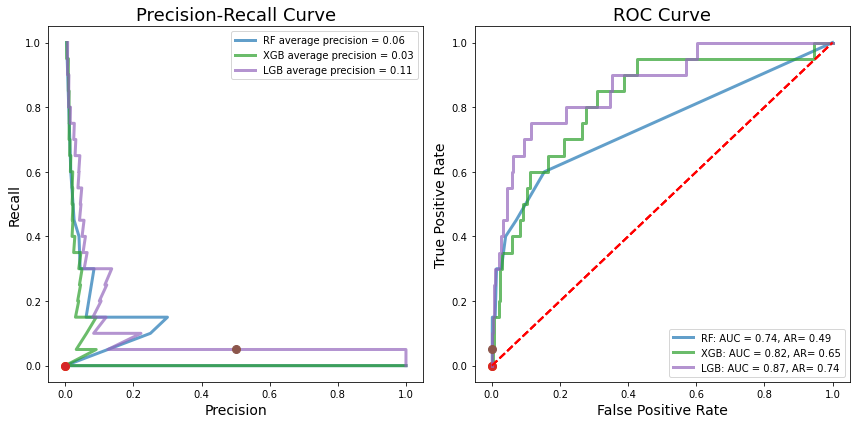

```python
results("Without Balancing")
```

The results of for these models are very poor and not reliable at all as the Precision-Recall curve indicates. This is dued to the fact that our dataset is extremely unbalanced.

#### 4.2 Balancing data

As in our dataset we observe 16324 “0” and 64 “1” it means that our data is highly unbalanced.

The observed class of “0” are the majority class as they make up the largest proportion of the dataset, while the class of “1” is the minority class.

An effective way to handle imbalanced data is to downsample and upweight the majority class.

- Downsampling means training on a disproportionately low subset of the majority class examples.
- Upweighting means adding an example weight to the downsampled class equal to the factor by which you downsampled.

##### Down-Sampling

```python
print("Minority Class =", len(dev[dev['Default Flag'] == 1]))
```

```
Minority Class = 62
```

```python
train_majority = dev[dev['Default Flag'] == 0]
train_minority = dev[dev['Default Flag'] == 1]
train_majority_downsampled = resample(train_majority, replace = False, n_samples = 62, random_state = 0)
train_downsampled = pd.concat([train_majority_downsampled, train_minority])
```

```python
train_downsampled.shape
```

```
(124, 21)
```

```python
X = train_downsampled.loc[:,dev.columns.isin(['EBIT','Growth in Leverage','ROA','CashRatio','Debt to Assets','IntExp to Total Assets',
             'Ebitda to Total Debt','Tangible Net Worth','REALGROWTHINSTOCKEQ','Free Cash Flow','Tot.Liab. To Tangible Net Worth'])]
y = train_downsampled['Default Flag']

X_train,X_test,y_train,y_test=train_test_split(X,y,test_size=0.3,random_state=0)
```

```
Down Sampling
######################### RF #########################
Training Accuracy = 1.000
Test Accuracy = 0.842
ROC_AUC_score : 0.944
AR_score: 0.889
AVG_PREC_score: 0.941
[[16  4]
 [ 2 16]]
--------------- CLASSIFICATION REPORT ---------------
              precision    recall  f1-score   support

           0       0.89      0.80      0.84        20
           1       0.80      0.89      0.84        18

    accuracy                           0.84        38
   macro avg       0.84      0.84      0.84        38
weighted avg       0.85      0.84      0.84        38

######################### XGB #########################
Training Accuracy = 1.000
Test Accuracy = 0.816
ROC_AUC_score : 0.914
AR_score: 0.828
AVG_PREC_score: 0.911
[[15  5]
 [ 2 16]]
--------------- CLASSIFICATION REPORT ---------------
              precision    recall  f1-score   support

           0       0.88      0.75      0.81        20
           1       0.76      0.89      0.82        18

    accuracy                           0.82        38
   macro avg       0.82      0.82      0.82        38
weighted avg       0.83      0.82      0.82        38

######################### LGB #########################
Training Accuracy = 0.988
Test Accuracy = 0.842
ROC_AUC_score : 0.942
AR_score: 0.883
AVG_PREC_score: 0.919
[[15  5]
 [ 1 17]]
--------------- CLASSIFICATION REPORT ---------------
              precision    recall  f1-score   support

           0       0.94      0.75      0.83        20
           1       0.77      0.94      0.85        18

    accuracy                           0.84        38
   macro avg       0.86      0.85      0.84        38
weighted avg       0.86      0.84      0.84        38
```

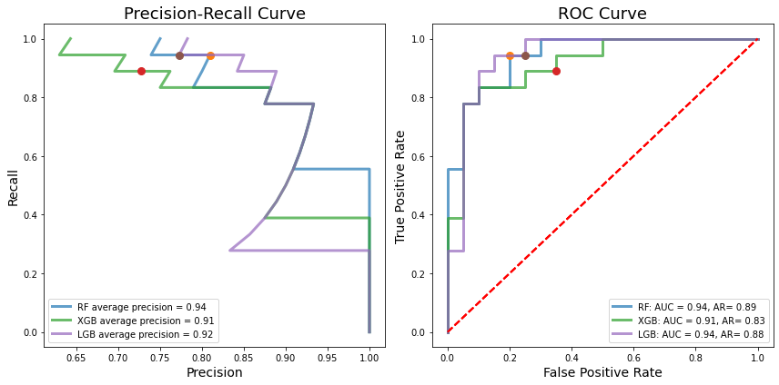

```python
results("Down Sampling")
```

##### Up-Sampling

```python
X = dev.loc[:,dev.columns.isin(['EBIT','Growth in Leverage','ROA','CashRatio','Debt to Assets','IntExp to Total Assets',
             'Ebitda to Total Debt','Tangible Net Worth','REALGROWTHINSTOCKEQ','Free Cash Flow','Tot.Liab. To Tangible Net Worth'])]
y = dev['Default Flag']

X_train_us,X_test,y_train_us,y_test=train_test_split(X,y,test_size=0.3,random_state=0)


#Now resample the train data
df_us = pd.concat([X_train_us, y_train_us], axis = 1)
train_majority = df_us[df_us['Default Flag'] == 0]
train_minority = df_us[df_us['Default Flag'] == 1]
train_majority.shape, train_minority.shape
```

```
((10970, 12), (42, 12))
```

```python
train_minority_upsampled = resample(train_minority, replace = True, n_samples = 10970, random_state = 0)
print(train_majority.shape, train_minority_upsampled.shape)
train_upsampled = pd.concat([train_minority_upsampled, train_majority])
X_train = train_upsampled.drop(columns = 'Default Flag')
y_train = train_upsampled['Default Flag']
```

```
(10970, 12) (10970, 12)
```

```
Up Sampling
######################### RF #########################
Training Accuracy = 1.000
Test Accuracy = 0.996
ROC_AUC_score : 0.726
AR_score: 0.452
AVG_PREC_score: 0.069
[[4699    1]
 [  19    1]]
--------------- CLASSIFICATION REPORT ---------------
              precision    recall  f1-score   support

           0       1.00      1.00      1.00      4700
           1       0.50      0.05      0.09        20

    accuracy                           1.00      4720
   macro avg       0.75      0.52      0.54      4720
weighted avg       0.99      1.00      0.99      4720

######################### XGB #########################
Training Accuracy = 1.000
Test Accuracy = 0.995
ROC_AUC_score : 0.806
AR_score: 0.612
AVG_PREC_score: 0.040
[[4698    2]
 [  20    0]]
--------------- CLASSIFICATION REPORT ---------------
              precision    recall  f1-score   support

           0       1.00      1.00      1.00      4700
           1       0.00      0.00      0.00        20

    accuracy                           1.00      4720
   macro avg       0.50      0.50      0.50      4720
weighted avg       0.99      1.00      0.99      4720

######################### LGB #########################
Training Accuracy = 1.000
Test Accuracy = 0.995
ROC_AUC_score : 0.814
AR_score: 0.628
AVG_PREC_score: 0.094
[[4697    3]
 [  19    1]]
--------------- CLASSIFICATION REPORT ---------------
              precision    recall  f1-score   support

           0       1.00      1.00      1.00      4700
           1       0.25      0.05      0.08        20

    accuracy                           1.00      4720
   macro avg       0.62      0.52      0.54      4720
weighted avg       0.99      1.00      0.99      4720
```

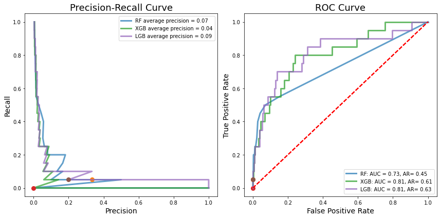

```python
results("Up Sampling")
```

Finally we observe a very good performance with a ROC_AUC=94% and AR=89% using RandoForestClassifier model using Down-Sampling technique. Also we can trust on this model since it also has a very high precision AVG_Prec=94%.

### 5. Conclusions

The main struggle of this project has been working with an extremely imbalanced dataset. The Logit Regression model implemented by Citi team was also having already quite good results, which made the range of improvement very narrow.

Eventhough and after a quite demanding understanding of their code and model, by a theoretical understanding of the variables, new ones were added to the original model and made a slight improvement on it.

In order to get an even bigger improvement 3 models were tested, with Random Forest Classifier, using Down-Sampling techinique to deal with the imbalance of the data, being the best one. A final Accuracy Ratio (AR) of 89% and an Area Under the ROC Curve (ROC_AUC) of 94% was reached, which is consider a quite good improvement.

### 6. Annex

- https://www.kaggle.com/code/prashant111/random-forest-classifier-tutorial/notebook
- https://www.datacamp.com/tutorial/xgboost-in-python
- https://www.kaggle.com/code/prashant111/lightgbm-classifier-in-python/notebook
- https://towardsdatascience.com/credit-risk-modeling-with-machine-learning-8c8a2657b4c4
- https://www.kaggle.com/code/saurav9786/feature-engineering-up-and-down-sampling/notebook